# BIGpicture vignette

Useful plot wrappers for ggplot2

Kim Dill-McFarland, kadm@uw.edu

version February 04, 2026

# Overview

This package provides a number of plot wrappers that create common bioinformatic analyses visualizations and work with results from our other packages, such as `kimma` and `SEARchways`. As such, you will need to install and load several packages to access example data.

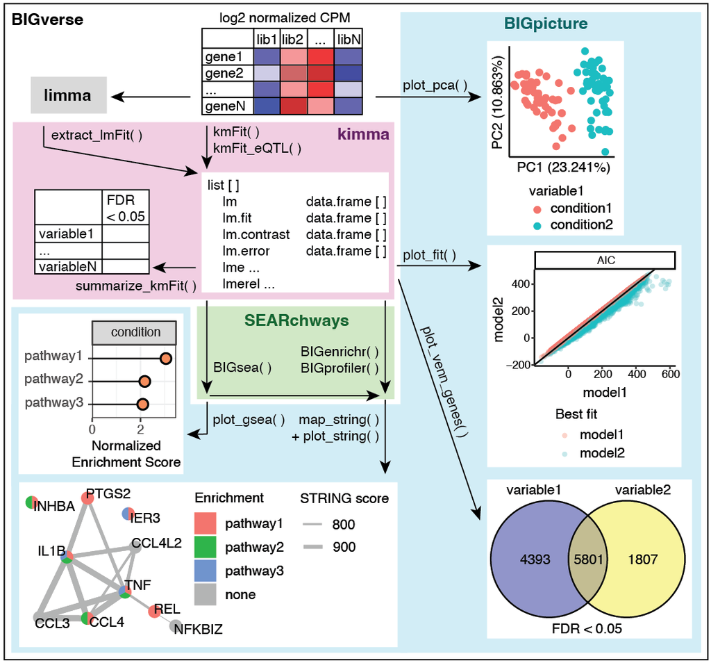

# Setup

## Software and packages

This pipeline should be completed in R version 4.5.1 (2025-06-13) or newer. Please also download the following packages.

```r
# CRAN packages
install.packages(c("tidyverse","patchwork"))

# Bioconductor packages
## These are dependencies for kimma that are beneficial to download separately
install.packages("BiocManager")
BiocManager::install(c("limma", "edgeR"))

# GitHub packages
install.packages("devtools")
devtools::install_github("BIGslu/kimma")
devtools::install_github("BIGslu/BIGpicture")
devtools::install_github("BIGslu/RNAetc")
devtools::install_github("BIGslu/SEARchways")
```

And load them into your current R session.

```r
library(tidyverse)
library(edgeR)
library(limma)
library(kimma)
library(BIGpicture)
library(SEARchways)
library(patchwork)
```

To ensure reproducibility with this document, set the random seed value.

```r
set.seed(651)
```

## Data background

Example data were obtained from media controls and human rhinovirus (HRV) infected human plasmacytoid dendritic cells. You can learn more about these data in

> Dill-McFarland KA, Schwartz JT, Zhao H, Shao B, Fulkerson PC, Altman MC, Gill MA. 2022. Eosinophil-mediated suppression and Anti-IL-5 enhancement of plasmacytoid dendritic cell interferon responses in asthma. J Allergy Clin Immunol. Epub ahead of print. doi: 10.1016/j.jaci.2022.03.025. — [GitHub](https://github.com/altman-lab/P259_pDC_public)

Specifically, this vignette uses bulk human RNA-seq processed from fastq to counts using [SEAsnake](https://bigslu.github.io/SEAsnake/vignette/SEAsnake_vignette.html) and counts to voom using [edgeR/limma](https://bigslu.github.io/tutorials/RNAseq/2.Hawn_RNAseq_counts.to.voom.html). This results in voom-normalized, log2 counts per million (CPM) gene expression and associated sample and gene metadata. In total, 6 donors and 1000 random genes were selected for this vignette. Actual donor identifiers have been altered for privacy.

## Load data

Unnormalized RNAseq counts and metadata.

```r
example.dat <- kimma::example.dat
names(example.dat)
```

```
## [1] "counts"  "samples" "genes"
```

Voom normalized RNAseq counts and metadata.

```r
example.voom <- kimma::example.voom
names(example.voom)
```

```
## [1] "genes"   "targets" "E"       "weights" "design"
```

kmFit model results.

```r
example.model <- BIGpicture::example.model
```

Create an additional kmFit model for plotting.

```r
example.model2 <- kimma::kmFit(
  dat = example.voom,
  model = "~virus*asthma + median_cv_coverage + (1|ptID)",
  run_lme = TRUE, use_weights = TRUE, metrics = TRUE)
```

```
## lme/lmerel model: expression~virus*asthma+median_cv_coverage+(1|ptID)
```

```
## Input: 12 libraries from 6 unique patients
```

```
## Model: 12 libraries
```

```
## Complete: 1000 genes
```

```
## Failed: 0 genes
```

Create example enrichment results.

```r
enrich <- SEARchways::flexEnrich(
  gene_list = list("HRV1"=names(SEARchways::example.gene.list$HRV1),
                   "HRV2"=names(SEARchways::example.gene.list$HRV2)),
  ID = "ENSEMBL", species = "human",
  collection = "H")

gsea <- SEARchways::BIGsea(
  gene_list = SEARchways::example.gene.list,
  ID = "ENSEMBL", species = "human",
  collection = "C2", subcollection = "CP")
```

```
## Running HRV1
```

```
## Running HRV2
```

# RNAseq data cleaning

## Mean-variance trend

Used in RNAseq data cleaning [counts to voom](https://bigslu.github.io/tutorials/RNAseq/2.Hawn_RNAseq_counts.to.voom.html) to visualize the association of expression on the X with variance on the Y.

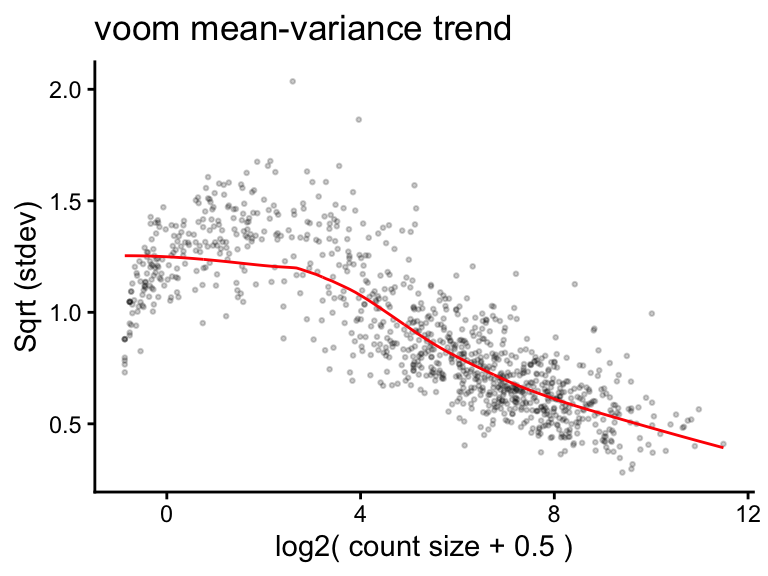

```r
plot_mv(dat = example.dat, design = "~ virus")
```

# PCA

## `plot_pca`: PCA all in one

Calculate, annotate, and plot a PCA representing gene expression. By default, we assume unique library IDs are contained in the column `libID`. Change this with the `libraryID` parameter.

When running on unnormalized data, transform the counts to log counts per million.

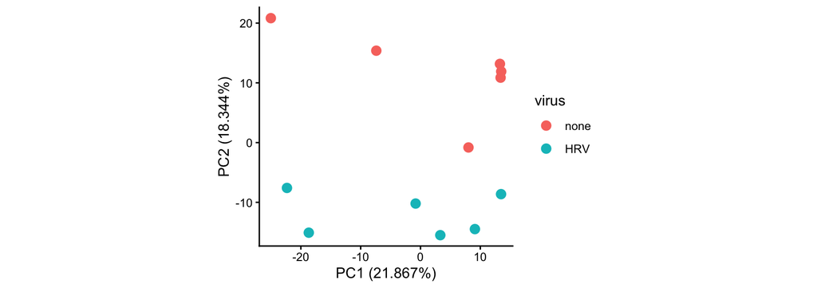

```r
plot_pca(dat = example.dat,
         vars = "virus",
         scale = TRUE,
         transform_logCPM = TRUE)
```

When running on normalized data, don’t transform the data (default).

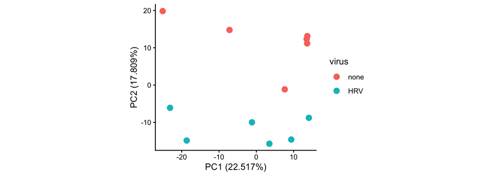

```r
plot_pca(dat = example.voom,
         vars = "virus",
         scale = TRUE)
```

Automatically identify outliers in PC space. See `outlier_group` parameter to define outliers within groups independently.

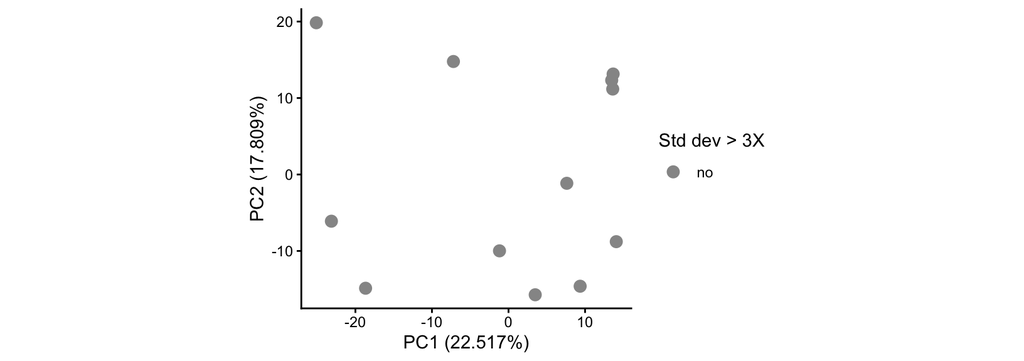

```r
plot_pca(dat = example.voom,
         vars = "outlier", outlier_sd = 3,
         scale = TRUE)
```

Plot multiple variables and visualize together with `patchwork`.

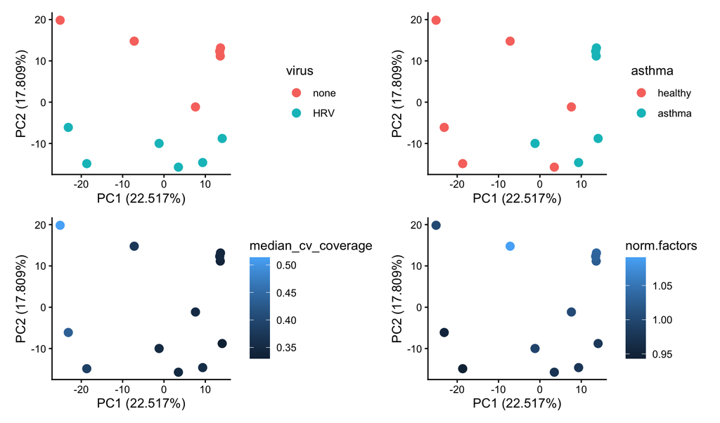

```r
plot_pca(dat = example.voom,
         vars = c("virus","asthma","median_cv_coverage", "norm.factors"),
         scale = TRUE) %>%
  patchwork::wrap_plots(nrow=2)
```

Other parameters

- View different PCs using `PCx` and `PCy`
- Define outliers within groups independently with `outlier_group`
- Define a difference unique identifier column with `libraryID`

## `calculate_pca`, `plot_pca2`, and `plot_pca_hm`: PCA in parts

If you want to calculate PCA and have it saved to your voom object for later use, you’ll want to use the `calculate_pca` function. Give it a voom object or a counts table and metadata to get back a voom object with PCA.scaled or PCA.unscaled slot (depending on if you set scaled=TRUE) or a list object with $counts, $samples, $PCA.scaled/PCA.unscaled. By default, we assume unique library IDs are contained in the column `libID`. Change this with the `libraryID` parameter.

When running on unnormalized data, transform the counts to log counts per million.

```r
example.dat.pca <- calculate_pca(dat = example.dat,
                                 scale = TRUE,
                                 transform_logCPM = TRUE)
```

`plot_pca2()` essentially works the same as `plot_pca()` except it doesn’t calculate the PCA, you have to run `calculate_pca()` first. If you set `scale = TRUE` in `calculate_pca()` you have to also specify it here:

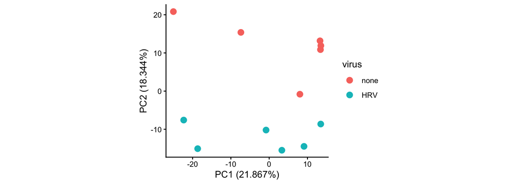

```r
plot_pca2(dat = example.dat.pca,scale = TRUE,
          vars=c("virus"))
```

`plot_pca_hm()` plots a heatmap of correlations between PCs and metadata variables. Also requires you to run `calculate_pca()` first.

```
## virus converted to numeric using factor levels.
```

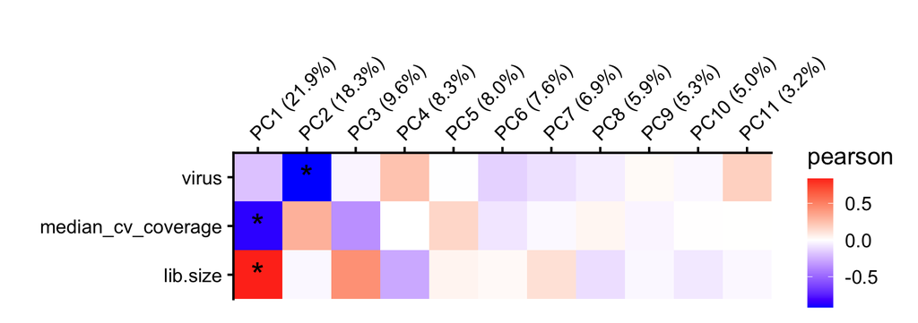

```r
plot_pca_hm(dat = example.dat.pca,
            vars = c("median_cv_coverage","lib.size", "virus"),
            scale=TRUE, flip_axes = FALSE)
```

# Linear modeling

## Model fit

### `plot_fit2`: Compare fit metrics

These functions use the output from `kimma::kmFit`.

Compare model fits between 2 models. Note that it is important to choose comparable models - this means the same number of samples and changing only 1 model attribute at a time e.g. adding a covariate, adding weights, adding a random effect, etc. Be careful if you have missing data. For example, if you have `~ variable` vs `~ variable + covariate` but the `covariate` has some missing data, changes in fit could be due to the `covariate` itself and/or the smaller sample size since samples missing *any* model variable are removed during modeling.

Here, we compare a model with and without kinship correction. The kmFit result has two model results (lme and lmerel), so you need only 1 model result input. Note the results printed in the console. These summarize genes better fit by one model or another. An absolute change in AIC > 7 is significant, change from 2-7 is moderate, and < 2 is non-significant. These cutoffs are also shown as red lines in the plot.

```r
names(example.model)
```

```
## [1] "lme"             "lmerel"          "lme.contrast"    "lmerel.contrast"
## [5] "lme.fit"         "lmerel.fit"
```

```
## Summary: AIC and BIC
```

```
##          Best fit Metric Total genes Mean delta Stdev delta
## 1 Nonsignif (< 2)    AIC        1000  0.2471154   0.3143377
```

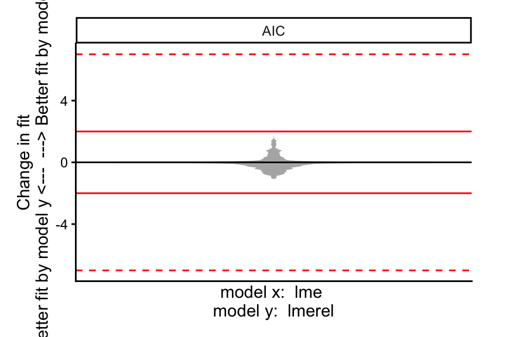

```r
plot_fit2(model_result = example.model,
          x="lme", y="lmerel", metrics = "AIC")
```

If you’re models are in two separate objects:

```
## Summary: AIC and BIC
```

```
##                                                                     Best fit
## 1 Moderate (2-7) lme_virus_asthma_median_cv_coverage_virus:asthma_(1 | ptID)
## 2                                                            Nonsignif (< 2)
## 3   Signif (> 7) lme_virus_asthma_median_cv_coverage_virus:asthma_(1 | ptID)
##   Metric Total genes Mean delta Stdev delta
## 1    AIC         727   4.439370   1.3281120
## 2    AIC         110   1.258108   0.5218337
## 3    AIC         163   9.782923   2.6771227
```

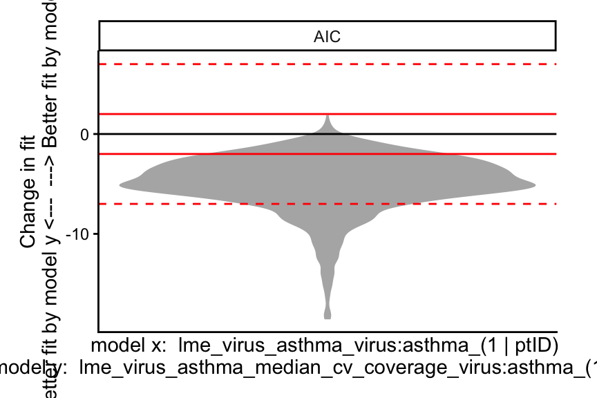

```r
plot_fit2(model_result = example.model, x="lme",
          model_result_y = example.model2, y="lme",
          metrics = "AIC")
```

Note that the model name is not very readable. You can change the labels.

```
## Summary: AIC and BIC
```

```
##                   Best fit Metric Total genes Mean delta Stdev delta
## 1 Moderate (2-7) +medianCV    AIC         727   4.439370   1.3281120
## 2          Nonsignif (< 2)    AIC         110   1.258108   0.5218337
## 3   Signif (> 7) +medianCV    AIC         163   9.782923   2.6771227
```

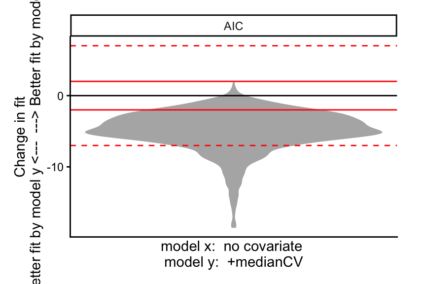

```r
plot_fit2(model_result = example.model, x="lme",
          x_label = "no covariate",
          model_result_y = example.model2, y="lme",
          y_label = "+medianCV",
          metrics = "AIC")
```

Plot a different metric. Choose anything in `example.model$lme.fit` or similar. Note that the cutoffs only apply to AIC and BIC

```
## Summary: AIC and BIC
```

```
##          Best fit Metric Total genes Mean delta Stdev delta
## 1 Nonsignif (< 2)    BIC        1000  0.2471154   0.3143377
```

```
## Summary: Other metrics
```

```
##   Best fit Metric Total genes Mean delta Stdev delta
## 1      lme    Rsq         273 0.01979372  0.02558724
## 2   lmerel    Rsq         466 0.01729597  0.01973940
## 3     none    Rsq         261 0.00000000  0.00000000
```

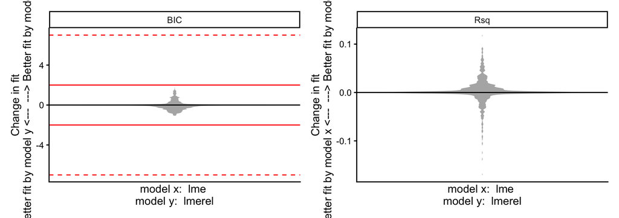

```r
plot_fit2(model_result = example.model,
          x="lme", y="lmerel",
          metrics = c("BIC","Rsq"))
```

Add dots to see outlying genes.

```
## Summary: AIC and BIC
```

```
##                   Best fit Metric Total genes Mean delta Stdev delta
## 1 Moderate (2-7) +medianCV    AIC         727   4.439370   1.3281120
## 2          Nonsignif (< 2)    AIC         110   1.258108   0.5218337
## 3   Signif (> 7) +medianCV    AIC         163   9.782923   2.6771227
```

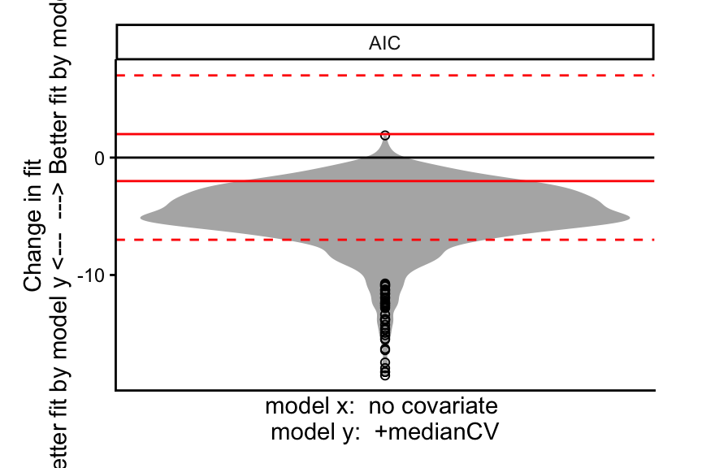

```r
plot_fit2(model_result = example.model, x="lme",
          x_label = "no covariate",
          model_result_y = example.model2, y="lme",
          y_label = "+medianCV",
          metrics = "AIC",
          outliers = TRUE)
```

Label genes with the largest changes in fit.

```
## Summary: AIC and BIC
```

```
##                   Best fit Metric Total genes Mean delta Stdev delta
## 1 Moderate (2-7) +medianCV    AIC         727   4.439370   1.3281120
## 2          Nonsignif (< 2)    AIC         110   1.258108   0.5218337
## 3   Signif (> 7) +medianCV    AIC         163   9.782923   2.6771227
```

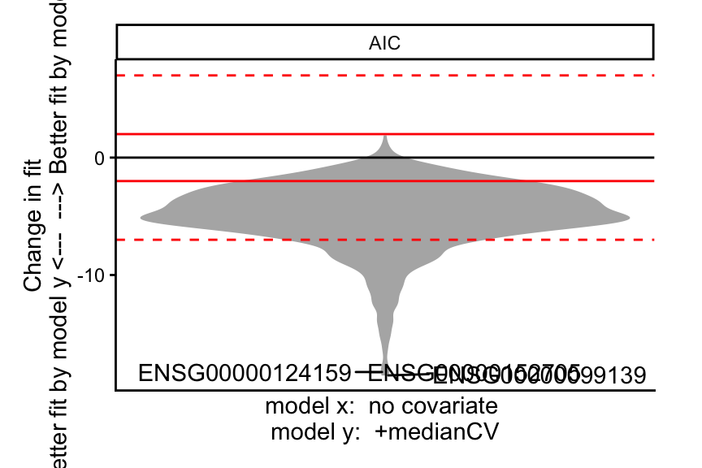

```r
plot_fit2(model_result = example.model, x="lme",
          x_label = "no covariate",
          model_result_y = example.model2, y="lme",
          y_label = "+medianCV",
          metrics = "AIC",
          label = 3)
```

Change the labels to another gene identifier.

```
## Summary: AIC and BIC
```

```
##                   Best fit Metric Total genes Mean delta Stdev delta
## 1 Moderate (2-7) +medianCV    AIC         727   4.439370   1.3281120
## 2          Nonsignif (< 2)    AIC         110   1.258108   0.5218337
## 3   Signif (> 7) +medianCV    AIC         163   9.782923   2.6771227
```

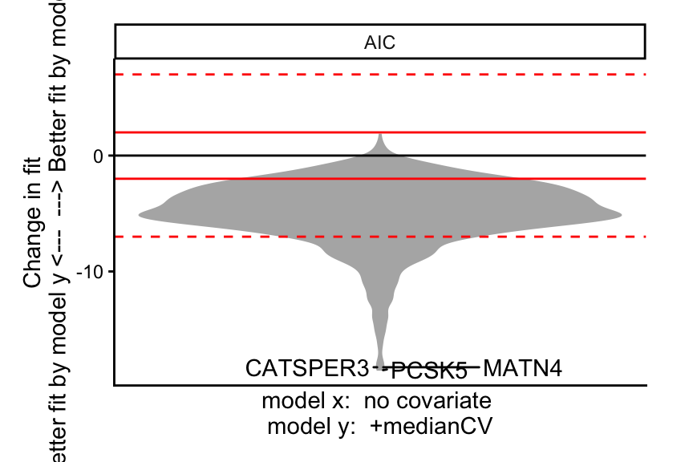

```r
plot_fit2(model_result = example.model, x="lme",
          x_label = "no covariate",
          model_result_y = example.model2, y="lme",
          y_label = "+medianCV",
          metrics = "AIC",
          label = 3,
          genes = example.voom$genes, genes_label = "hgnc_symbol")
```

Only plot a subset of genes.

```
## Summary: AIC and BIC
```

```
##                   Best fit Metric Total genes Mean delta Stdev delta
## 1 Moderate (2-7) +medianCV    AIC          71   4.398087   1.2628561
## 2          Nonsignif (< 2)    AIC          12   1.380337   0.5232679
## 3   Signif (> 7) +medianCV    AIC          17   9.942274   2.3146413
```

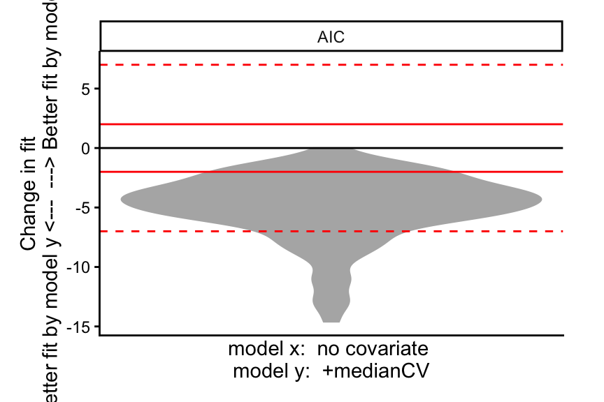

```r
plot_fit2(model_result = example.model, x="lme",
          x_label = "no covariate",
          model_result_y = example.model2, y="lme",
          y_label = "+medianCV",
          metrics = "AIC",
          subset_genes = example.voom$genes$geneName[1:100])
```

## Significant results

### `plot_volcano`: Volcano plot

Plot all variables from one model.

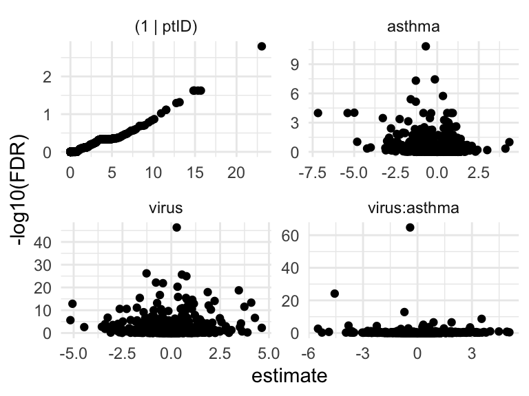

```r
plot_volcano(model_result = example.model, model = "lme")
```

Select variable(s) of interest.

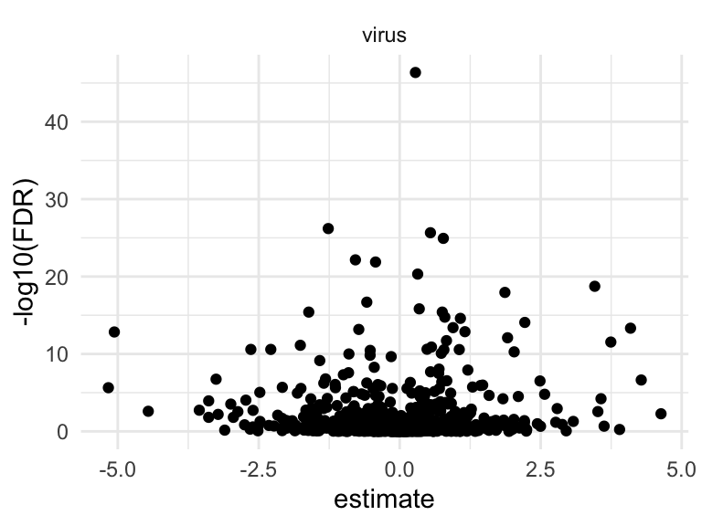

```r
plot_volcano(model_result = example.model, model = "lme",
             variables = "virus")
```

Plot uncorrected P-values instead of FDR.

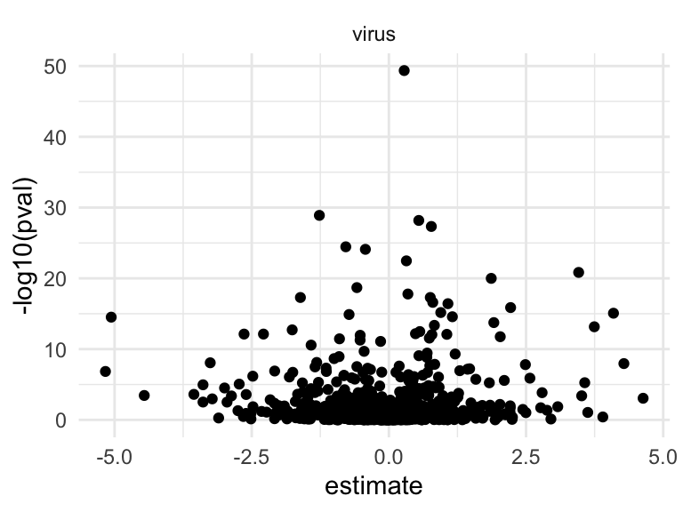

```r
plot_volcano(model_result = example.model, model = "lme",
             variables = "virus",
             y="pval")
```

Color significant genes based on FDR and/or estimate.

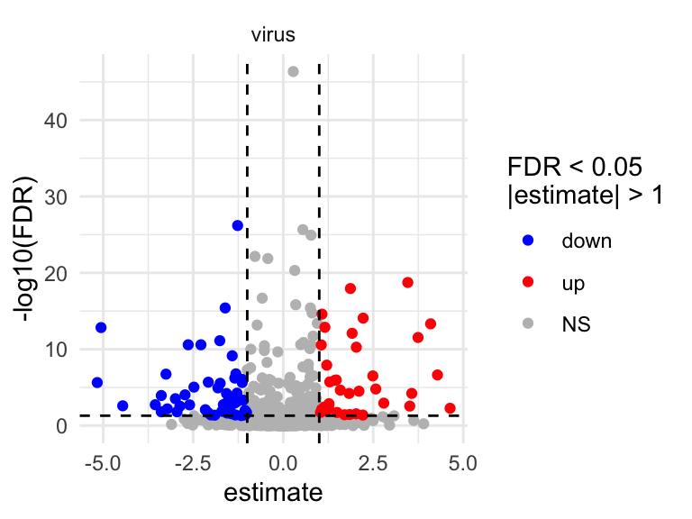

```r
plot_volcano(model_result = example.model, model = "lme",
             variables = "virus",
             x_cutoff = 1, y_cutoff = 0.05)
```

Label most significant genes.

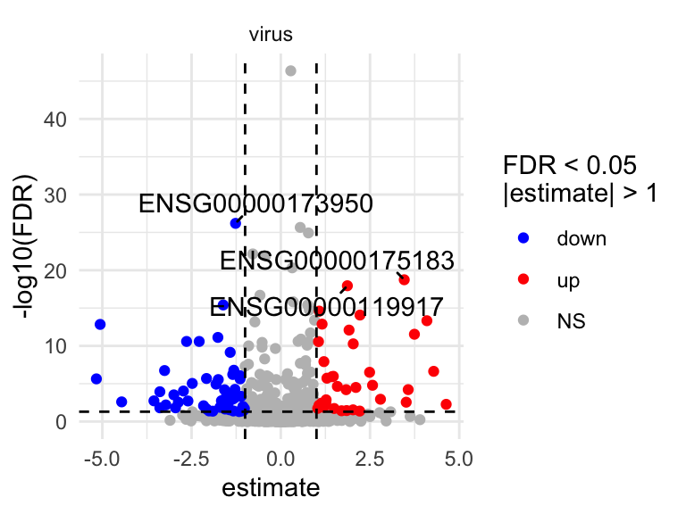

```r
plot_volcano(model_result = example.model, model = "lme",
             variables = "virus",
             x_cutoff = 1, y_cutoff = 0.05,
             label = 3)
```

Change the gene labels to a different gene indentifier.

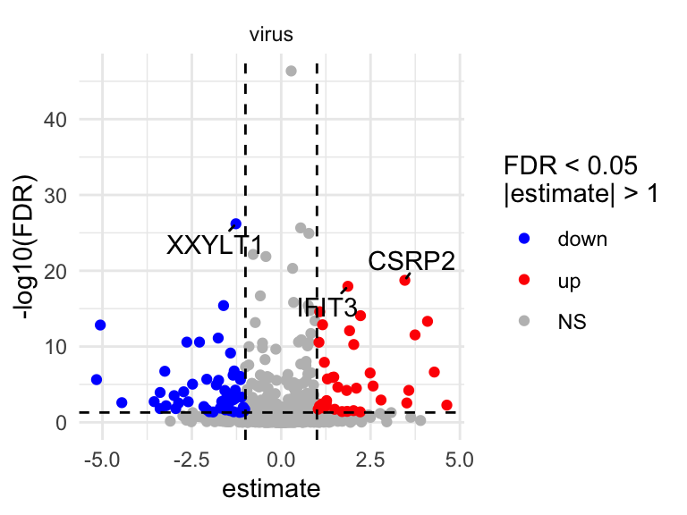

```r
plot_volcano(model_result = example.model, model = "lme",
             variables = "virus",
             x_cutoff = 1, y_cutoff = 0.05,
             label = 3,
             genes = example.voom$genes,
             genes_label = "hgnc_symbol")
```

### `plot_venn_genes`: Venn plot of DEGs

Functions the same as `plot_upset_genes`.

Plot all variables at multiple FDR cutoffs.

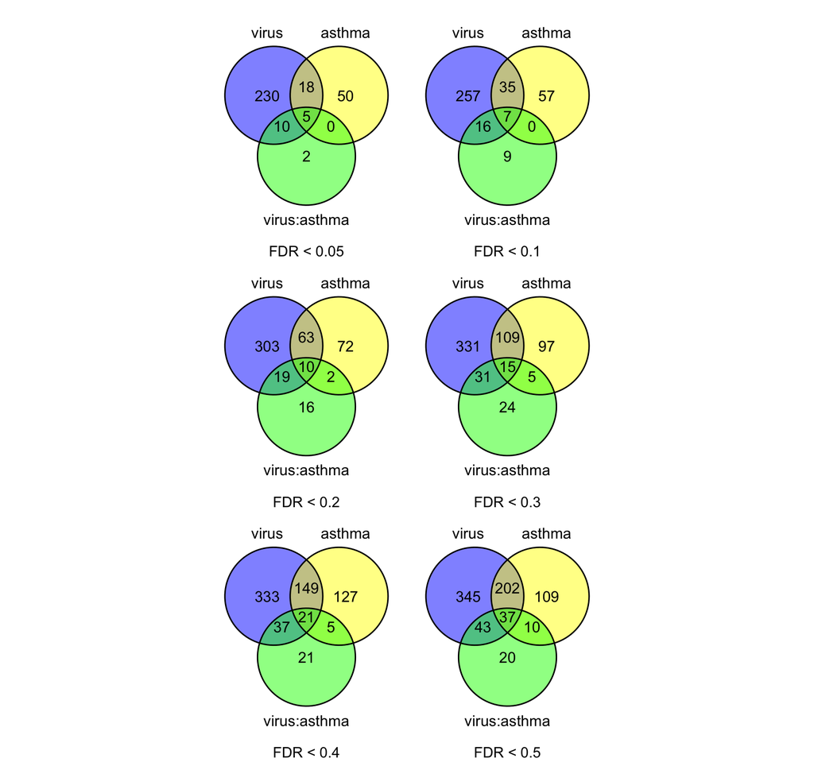

```r
plot_venn_genes(model_result = example.model,
                models = "lme")$venn %>%
  patchwork::wrap_plots(ncol=2)
```

Select specific FDR cutoff(s).

```
## $venn
## $venn$`0.05`
```

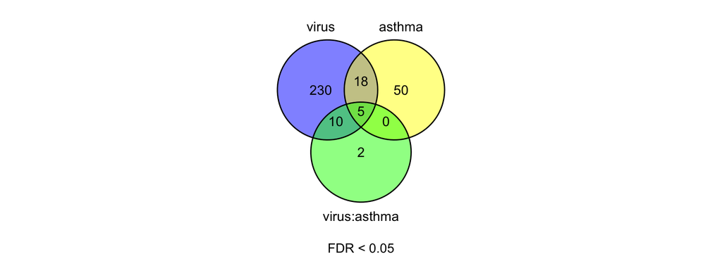

```r
plot_venn_genes(model_result = example.model,
                models = "lme",
                fdr_cutoff = 0.05)
```

Select variable(s) of interest.

```
## $venn
## $venn$`0.05`
```

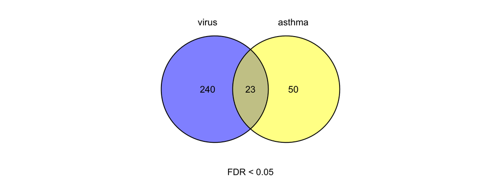

```r
plot_venn_genes(model_result = example.model,
                models = "lme",
                fdr_cutoff = 0.05,
                variables = c("asthma","virus"))
```

If you’re using a contrasts model, specify contrasts instead.

```
## $venn
## $venn$`0.05`
```

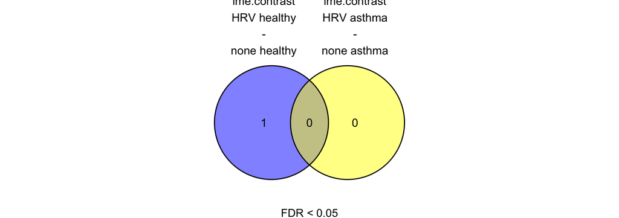

```r
plot_venn_genes(model_result = example.model,
                models = "lme.contrast",
                fdr_cutoff = 0.05,
                contrasts = c("HRV healthy - none healthy",
                              "HRV asthma - none asthma"))
```

Include the random effect and/or intercept if the model has one.

```
## $venn
## $venn$`0.05`
```

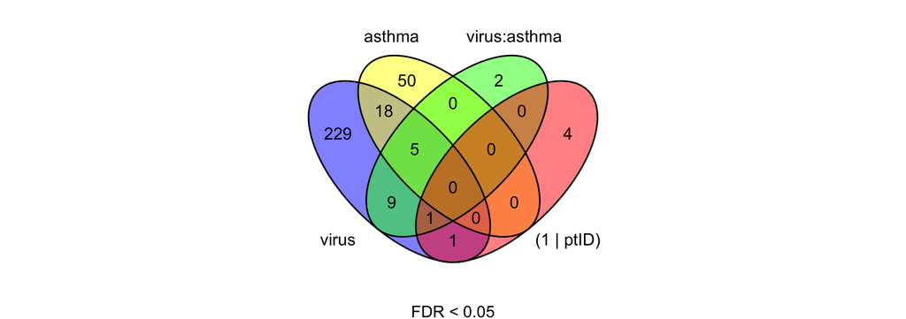

```r
plot_venn_genes(model_result = example.model,
                models = "lme",
                fdr_cutoff = 0.05,
                random = TRUE, intercept = TRUE)
```

Save the genes in each part of the Venn’s overlap for downstream analyses.

```
## $`0.05`
```

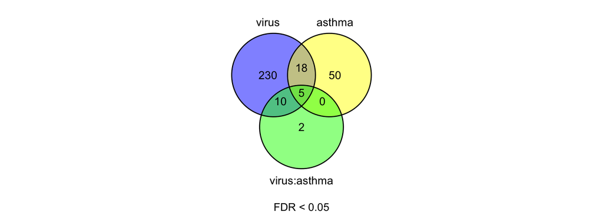

```r
venn_result <- plot_venn_genes(model_result = example.model,
                models = "lme",
                fdr_cutoff = 0.05,
                return_genes = TRUE)
venn_result$venn
```

```r
venn_result$gene$`0.05` %>% head
```

```
##              gene virus:asthma asthma virus
## 1 ENSG00000002587         <NA>   <NA>     Y
## 2 ENSG00000013810         <NA>      Y     Y
## 3 ENSG00000023287         <NA>   <NA>     Y
## 4 ENSG00000034510         <NA>   <NA>     Y
## 5 ENSG00000050130         <NA>   <NA>     Y
## 6 ENSG00000054118         <NA>   <NA>     Y
```

Compare DEGs in two different models.

```
## $venn
## $venn$`0.05`
```

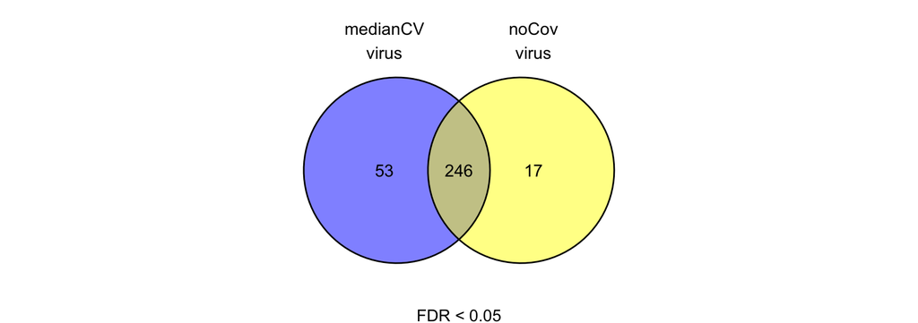

```r
plot_venn_genes(model_result = list("noCov"=example.model,
                                    "medianCV"=example.model2),
                models = "lme",
                variables = "virus",
                fdr_cutoff = 0.05)
```

Note that labels might get cutoff if they are too long, so you may need to expand the plot limits. A good way to do this is to first find the current limits by adding a theme with xy axes and then setting `lims` on the single Venn result. For example, here we expand the y limits (even though the labels are not cutoff).

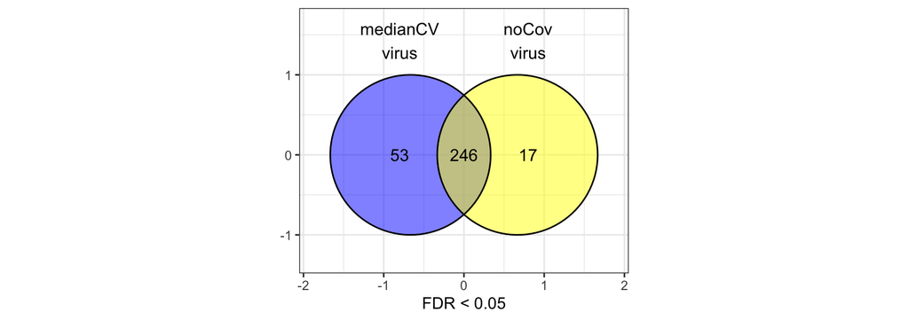

```r
plot_venn_genes(model_result = list("noCov"=example.model,
                                    "medianCV"=example.model2),
                models = c("lme","lme"),
                variables = "virus",
                fdr_cutoff = 0.05)$venn$`0.05` +
  theme_bw()
```

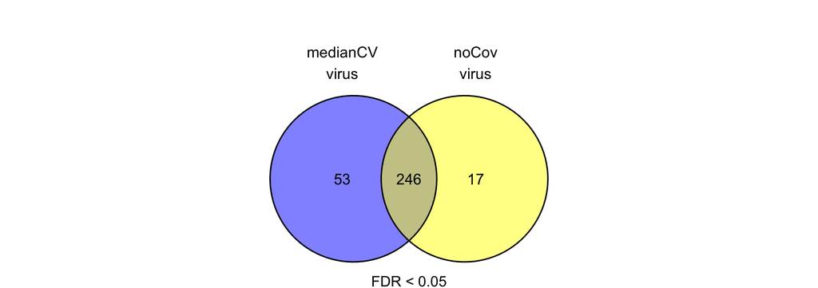

```r
plot_venn_genes(model_result = list("noCov"=example.model,
                                    "medianCV"=example.model2),
                models = c("lme","lme"),
                variables = "virus",
                fdr_cutoff = 0.05)$venn$`0.05` +
  lims(y=c(-1,2))
```